# 통계밥법론2 Chap5 실습코드

### 5.5.2 Causal models

*Example 5.9: Martial status and pre-and extramarital sex*

```r
data("PreSex", package =  "vcd")
structable(Gender + PremaritalSex + ExtramaritalSex ~ MaritalStatus, data = PreSex)
```

```
##               Gender          Women             Men
##               PremaritalSex     Yes      No     Yes      No
##               ExtramaritalSex   Yes  No Yes  No Yes  No Yes  No
## MaritalStatus
## Divorced                         17  54  36 214  28  60  17  68
## Married                           4  25   4 322  11  42   4 130
```

`PreSex`데이터는 혼전 및 혼외 성관계와 이혼에 대해 나타나는 데이터로 `vcd`패키지 안에 포함돼있다.

- MartialStatus: 결혼 여부 (Factor variable - Divorced, Married)
- ExtramaritialSex: 혼외 성관계 여부 (Factor variable - Yes, No)
- PremartialSex 혼전 성관계 여부 (Factor variable - Yes, No)
- Gender: 성별 (Facotr variable - Women, Men)

`PreSex`데이터를 `structable`함수를 이용하여 복잡한 형테의 분할표를 한 눈에 볼 수 있게 변환하였다.  
남성과 여성 모두 혼전, 혼외 성관계 여부가 No인 빈도가 가장 높았다.

```r
PreSex <- aperm(PreSex, 4 : 1)
```

`aperm`함수를 이용하여 주어진 `PreSex`데이터의 범주형 변수의 수준을 재지정하였다.

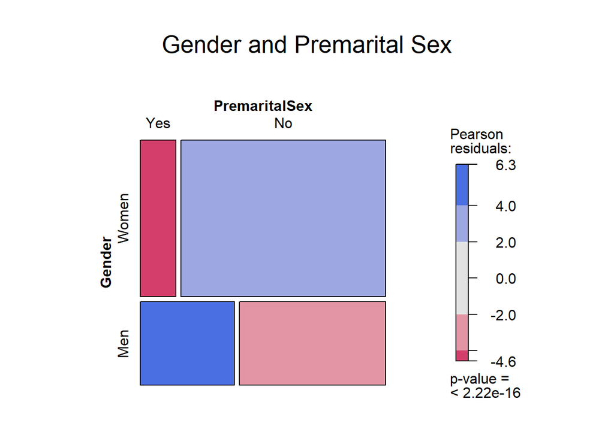

```r
mosaic(margin.table(PreSex, 1 : 2), shade = TRUE,
       main = "Gender and Premarital Sex")
```

PreSex의 1번째 2번째 데이터를 통해 모자이크 플롯을 그려보았다.  
**Gender = Women, Premarital Sex = Yes**, **Gender = Men, Premarital Sex = No**인 경우 관찰빈도가 기대빈도 보다 낮았고,  
**Gender = Women, Premarital Sex = No**, **Gender = Men, Premarital Sex = Yes**인 경우 관찰빈도가 기대빈도 보다 높았다.  
이를 통해, 성별이 여성인 경우 Premarital Sex 경험이 적은 것으로 보였으며, 성별이 남성인 경우 Premarital Sex 경험이 많은 것 처럼 보이는 것을 확인할 수 있었다.  
유의확률은 유의수준 0.05보다 작으므로 귀무가설을 기각한다. 따라서, **PremaritalSex**와 **Gender**는 독립이 아니며, 서로 연관성이 있다고 할 수 있다.

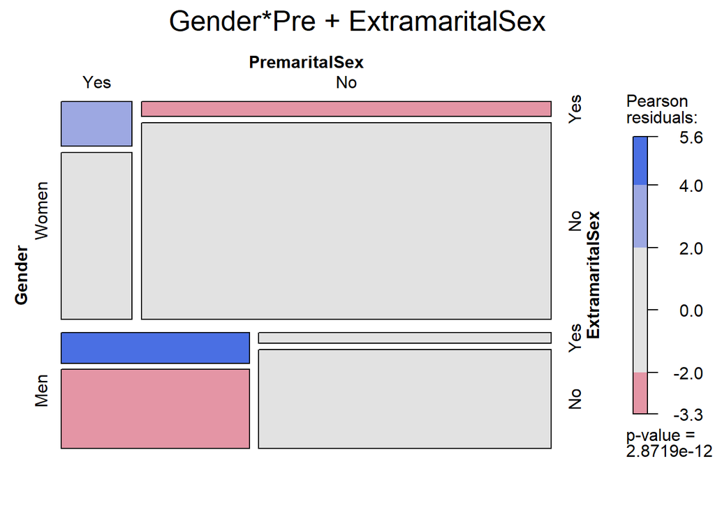

```r
mosaic(margin.table(PreSex, 1 : 3),
       expected = ~ Gender * PremaritalSex + ExtramaritalSex, main = "Gender*Pre + ExtramaritalSex")
```

**ExtramaritalSex**변수까지 고려하여 모자이크 플롯을 다시 한 번 나타내었다.  
위의 모델은 **ExtramaritalSex**변수가 **Gender**, **PremartialSex**에 대해 공동적으로 독립이라는 가정을 한 후, 적합시킨 모델이다.  
위의 모자이크 플롯을 살펴본 결과, **PremartialSex = Yes인 남성**이 **PremartialSex =No인 남성**에 비해 **ExtramaritalSex 가능성이 더 높은 것**을 확인할 수 있다.  
유의확률은 유의수준 0.05보다 작으므로 귀무가설을 기각한다. 따라서, **ExtramaritalSex**가 **Gender**, **PremartialSex**에 대해서 공동적으로 독립이 아니라는 것을 확인할 수 있다.

```r
loddsratio(margin.table(PreSex, 1 : 3), stratum = 1,
           log = FALSE)
```

```
##  odds ratios for Gender and PremaritalSex by ExtramaritalSex
##
##       Yes        No
## 0.2826923 0.2861062
```

또한, 오즈비를 고려해봤을때, **ExtramaritalSex**는 **PremartialSex**의 여부에 따라 달라지지만, **성별**에 따라 달라지지 않는 것을 확인할 수 있다.

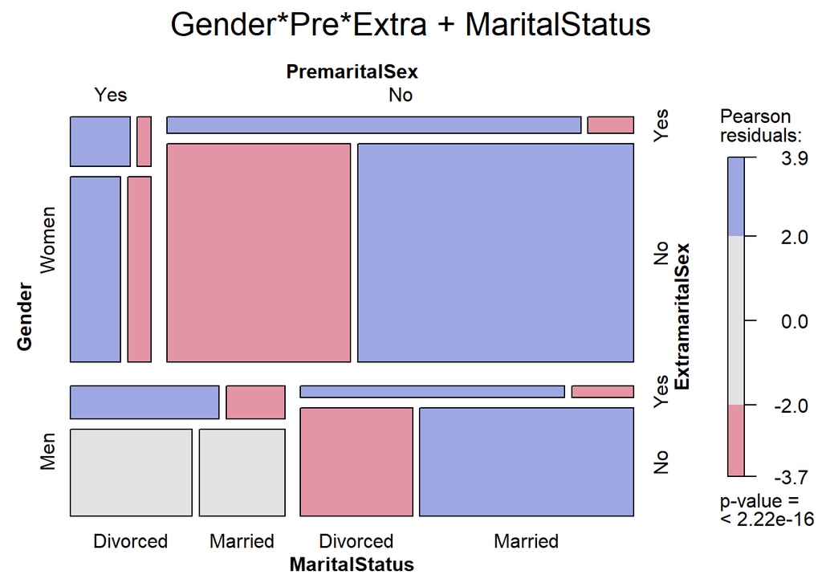

```r
mosaic(PreSex, expected = ~ Gender * PremaritalSex * ExtramaritalSex + MaritalStatus, main = "Gender*Pre*Extra + MaritalStatus")
```

**MaritalStatus** 변수까지 고려한 모자이크 플롯을 그려보았다.  
위의 모델은 **MaritalStatus**변수가 **ExtramaritalSex**, **PremaritalSex**, **Gender**에 대해서 공동적으로 독립이라는 가정을 한 후, 적합시킨 모형이다.

**MaritalStatus = Married**일 때, 남성과 여성 모두 **ExtramaritalSex**가 Yes보다 No인 빈도가 더 많이 나타나는 것을 확인할 수 있었으며, **MaritalStatus = Divorced**일 때, 남성과 여성 모두, **ExtramaritalSex**가 Yes인 빈도가 더 많이 나타나는 것 또한 확인할 수 있었다.

유의확률은 유의수준 0.05보다 작으므로 귀무가설을 기각한다. 따라서, **MaritalStatus**변수가 **ExtramaritalSex**, **PremaritalSex**, **Gender**에 대해서 공동적으로 독립이라고 할 수 없다.

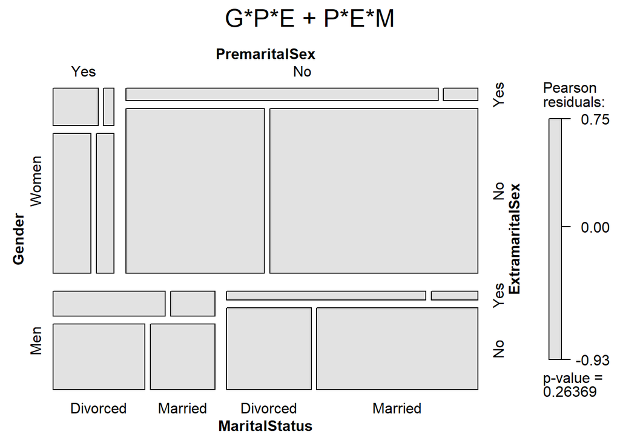

```r
mosaic(PreSex,
       expected = ~ Gender * PremaritalSex * ExtramaritalSex + MaritalStatus * PremaritalSex * ExtramaritalSex, main = "G*P*E + P*E*M")
```

### 5.5.3 Partial association

*Example 5.10: Employment status data*

```r
data("Employment", package = "vcd")
structable(Employment)
```

```
##                              EmploymentLength <1Mo 1-3Mo 3-12Mo 1-2Yr 2-5Yr >5Yr
## EmploymentStatus LayoffCause
## NewJob           Closure                         8    35     70    62    56   38
##                  Replaced                       40    85    181    85   118   56
## Unemployed       Closure                        10    42     86    80    67   35
##                  Replaced                       24    42     41    16    27   10
```

`Employment`데이터는 1974년 해고된 직원 1314명을 연구한 데이터로 `vcd`패키지안에 포함돼있다.

- EmploymentStatus: 고용상태 (Factor variable - NewJob, Unemployed)
- EmploymentLength: 해고 당시 고용기간 (Factor variable - <1Mo, 1-3Mo, 3-12Mo, 1-2Yr, 2-5Yr, >5Yr)
- LayoffCause: 해고 원인 (Factor variable - Closure, Replaced)

*Employment*데이터를 로드한 후, `structable`함수를 통해 데이터 탐색을 진행하였다.

```r
loglm(~ EmploymentStatus + EmploymentLength * LayoffCause, data = Employment)
```

```
## Call:
## loglm(formula = ~EmploymentStatus + EmploymentLength * LayoffCause,
##     data = Employment)
##
## Statistics:
##                       X^2 df P(> X^2)
## Likelihood Ratio 172.2764 11        0
## Pearson          165.7020 11        0
```

`loglm`을 통해 **EmploymentStatus**가 **EmploymentLength,LayoffCause**과 독립이라는 가정을 하는 **[EmploymentStatus] [EmploymentLength LayoffCause]**모형을 적합시켰다.  
적합시킨 모형의 유의확률이 유의수준 0.05보다 작으므로 귀무가설을 기각한다. 따라서, **EmploymentStatus**는 **EmploymentLength,LayoffCause**과 독립이 아니라고 할 수 있다.

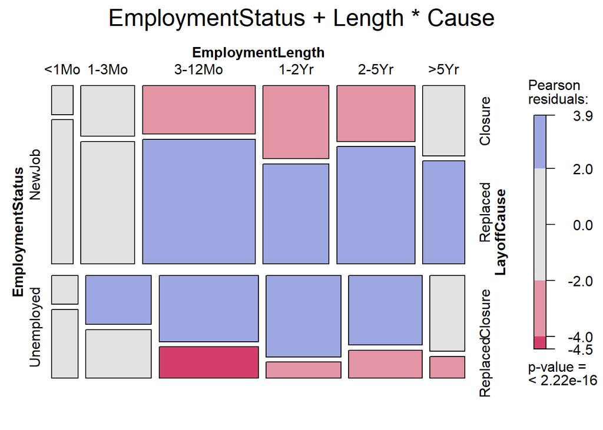

```r
mosaic(Employment, shade = TRUE,
       expected = ~ EmploymentStatus + EmploymentLength * LayoffCause, main = "EmploymentStatus + Length * Cause")
```

위 모형의 **모자이크 플롯**을 그린 결과는 위와 같다.  
**LayoffCause = Closure**로 인한 해고인 경우 **EmploymentLength에 관계없이 EmploymentStatus = Unemployed 빈도가 더 높은 것**을 확인할 수 있으며, **LayoffCause = Replaced이면서, 3개월 이상의 EmploymentLength인 경우, Newjob일 빈도가 높은 것**을 확인할 수 있었다.

```r
loglm(~ EmploymentStatus * LayoffCause + EmploymentLength * LayoffCause, data = Employment)
```

```
## Call:
## loglm(formula = ~EmploymentStatus * LayoffCause + EmploymentLength *
##     LayoffCause, data = Employment)
##
## Statistics:
##                       X^2 df    P(> X^2)
## Likelihood Ratio 24.63004 10 0.006092652
## Pearson          26.07206 10 0.003644473
```

이번에는 **LayoffCause**이 제어될 때, **EmploymentStatus**와 **EmploymentLength**은 서로 독립이라는 가정을 하는 **[EmploymentStatus][LayoffCause] [EmploymentLength][LayoffCause]** 모형을 적합시켜 보았다.

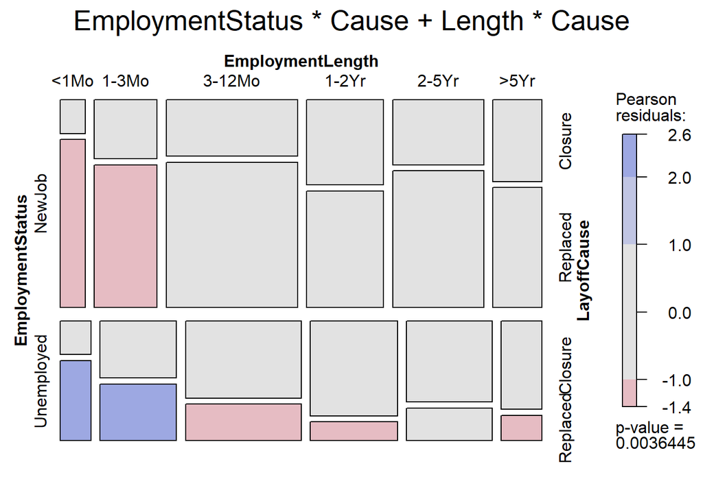

```r
mosaic(Employment, shade = TRUE, gp_args = list(interpolate = 1 : 4), expected = ~ EmploymentStatus * LayoffCause + EmploymentLength * LayoffCause,
       main = "EmploymentStatus * Cause + Length * Cause")
```

모자이크 플롯을 살펴본 결과, **EmploymentLength가 3달 이하인 경우, LayoffCause = Replaced라고 하더라도, Unemployed일 빈도**가 높았다.

```r
mods.list <-
  apply(Employment, "LayoffCause",
        function(x) loglm(~ EmploymentStatus + EmploymentLength, data = x))
mods.list
```

```
## $Closure
## Call:
## loglm(formula = ~EmploymentStatus + EmploymentLength, data = x)
##
## Statistics:
##                       X^2 df  P(> X^2)
## Likelihood Ratio 1.478564  5 0.9155302
## Pearson          1.483492  5 0.9149669
##
## $Replaced
## Call:
## loglm(formula = ~EmploymentStatus + EmploymentLength, data = x)
##
## Statistics:
##                       X^2 df     P(> X^2)
## Likelihood Ratio 23.15148  5 0.0003157832
## Pearson          24.58856  5 0.0001672716
```

결과를 더 자세히 살펴보기 위해, 해고 원인의 두 수준에 대해서 **EmploymentStatus**,**EmploymentLength**에 대한 `loglm`개별 모델을 적합시켰다.

**Layoffcause = Closure**일때의 `loglm`결과는 유의확률이 모두 유의수준 0.05보다 크므로 귀무가설을 기각하지 못한다. 따라서, **EmploymentLength**와 **EmploymentStatus**는 서로 독립이라고 할 수 있다.

**Layoffcause = Replaced**일때의 `loglm`결과는 유의확률이 모두 유의수준 0.05보다 작으므로 귀무가설을 기각한다. 따라서, **EmploymentLength**와 **EmploymentStatus**는 서로 독립이 아니라고 할 수 있다.

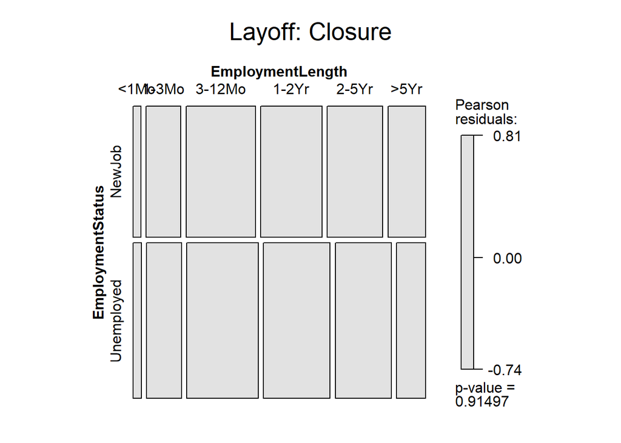

```r
mosaic(Employment[,,"Closure"], shade = TRUE,
       gp_args = list(interpolate = 1 : 4),
       margin = c(right = 1), main = "Layoff: Closure")
```

모자이크 플롯을 통해서도 두 로그선형모델의 결과를 쉽게 이해할 수 있다.  
**Layoffcause = Closure**인 경우, 특별한 패턴은 보이지 않고 **EmploymentLength**과 **EmploymentStatus**는 독립인 것처럼 보인다.

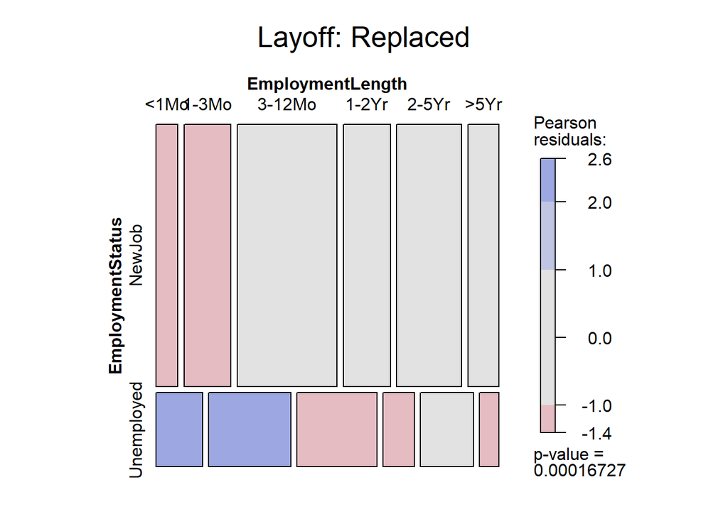

```r
mosaic(Employment[,,"Replaced"],shade = TRUE,
       gp_args = list(interpolate = 1 : 4),
       margin = c(right = 1), main = "Layoff: Replaced")
```

**Layoffcause = Replaced**인 경우, **EmploymentLength**가 3개월 이하인 사람의 경우 **EmploymentStatus = NewJob**일 빈도가 낮지만 **EmploymentLength**가 3개월을 초과하는 **EmploymentStatus = Unemployed** 빈도가 상당히 낮은 것을 확인할 수 있다.

이렇게 전체적인 모델을 살펴볼때에는 드러나지 않는 패턴이 부분 관계에 대해 별도의 모델을 적합시키게 되면 쉽게 패턴을 찾을 수 있다.

*Example 5.11: Corporal punishment data*

```r
data("Punishment", package = "vcd")
head(Punishment)
```

```
##   Freq attitude memory  education   age
## 1    1       no    yes elementary 15-24
## 2    3       no    yes elementary 25-39
## 3   20       no    yes elementary   40-
## 4    2       no    yes  secondary 15-24
## 5    8       no    yes  secondary 25-39
## 6    4       no    yes  secondary   40-
```

```r
str(Punishment, vec.len = 2)
```

```
## 'data.frame':    36 obs. of  5 variables:
##  $ Freq     : num  1 3 20 2 8 ...
##  $ attitude : Factor w/ 2 levels "no","moderate": 1 1 1 1 1 ...
##  $ memory   : Factor w/ 2 levels "yes","no": 1 1 1 1 1 ...
##  $ education: Factor w/ 3 levels "elementary","secondary",..: 1 1 1 2 2 ...
##  $ age      : Factor w/ 3 levels "15-24","25-39",..: 1 2 3 1 2 ...
```

`punishment`데이터는 아동 체벌에 대한 1,456명의 무작위 표본에 관한 데이터로 `vcd`패키지에 포함돼있다.

- Freq: 빈도 (Discrete variable)
- attitude: 아이들에 대한 처벌 여부 (Factor variable - no,moderate)
- memory: 어릴때 체벌에 대한 기억이 있는지에 대한 여부 (Factor variable - yes, no)
- education: 최종학력 (Factor variable - elementary, secondary, high)
- age: 조사된 나이 그룹 (Factor variable - 15~24, 25~39, 40~)

```r
pun <- xtabs(Freq ~ memory + attitude + age + education, data = Punishment)
dimnames(pun) <- list(
  Memory = c("yes","no"),
  Attitude = c("no","moderate"),
  Age = c("15-24", "25-39", "40+"),
  Education = c("Elementary", "Secondary", "High"))
```

```r
(mod.cond <- loglm(~ Memory * Age * Education +
                     Attitude * Age * Education, data = pun))
```

```
## Call:
## loglm(formula = ~Memory * Age * Education + Attitude * Age *
##     Education, data = pun)
##
## Statistics:
##                       X^2 df     P(> X^2)
## Likelihood Ratio 39.67937  9 8.685120e-06
## Pearson          34.60409  9 6.996362e-05
```

`loglm`함수를 사용하여 **Age**, **Education**이 제어될 때, **Memory**, **Attitude**가 조건부 독립이라는 가정을 한 후 로그선형모델에 적합시켜 보았다.  
적합시킨 모형의 유의확률이 모두 유의수준 0.05보다 작으므로 귀무가설을 기각한다.  
따라서, **Age**, **Education**이 제어될 때, **Memory**, **Attitude**가 조건부 독립이 아니라고 할 수 있다. 즉, **Memory**와 **Attitude**는 서로 연관이있다고 할 수 있다.

```r
set.seed(1071)
coindep_test(pun, margin = c("Age", "Education"),
             indepfun = function(x) sum(x^2), aggfun = sum)
```

```
##
##  Permutation test for conditional independence
##
## data:  pun
## f(x) = 34.604, p-value < 2.2e-16
```

`coindep_test`함수를 이용하여 분할표의 conditional 독립성 검정을 진행할수도 있다. `coindep_test`의 유의확률 또한 유의수준 0.05보다 작으므로 귀무가설을 기각한다. 따라서 **Memory**와 **Attitude**는 서로 독립이 아니라고 할 수 있다.

```r
mods.list <- apply(pun, c("Age", "Education"),
                   function(x) loglm(~ Memory + Attitude, data = x)$pearson)
```

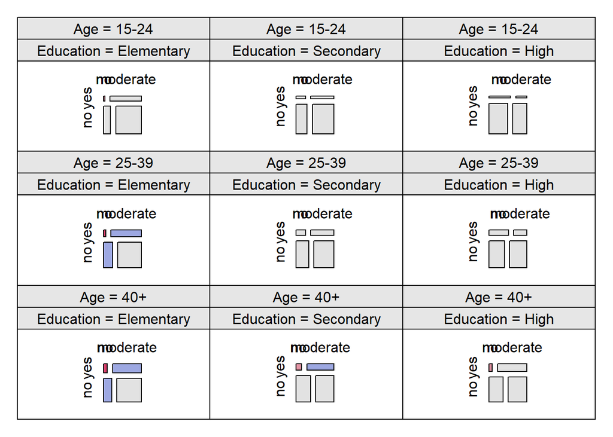

```r
set.seed(1071)
pun_cotab <- cotab_coindep(pun, condvars = 3 : 4, type = "mosaic",
                           varnames = FALSE, margins = c(2,1,1,2),
                           test = "sumchisq", interpolate = 1 : 2)
cotabplot(~ Memory + Attitude | Age + Education,
          data = pun, panel = pun_cotab)
```

`cotabplot`함수를 이용하여 여러 개의 모자이크 플롯을 나이와 교육수준에 따라 패널별로 살펴볼 수 있게 하였다.  
교육수준이 Elementary인 경우, **Attitude = No, Memory = Yes**인 빈도가 낮은 경향을 보이는 것을 확인할 수 있었고 나이가 25세 이상인 경우, **Attitude = moderate, Memory = yes**인 빈도가 높은 경향을 보이는 것을 알 수 있었다.

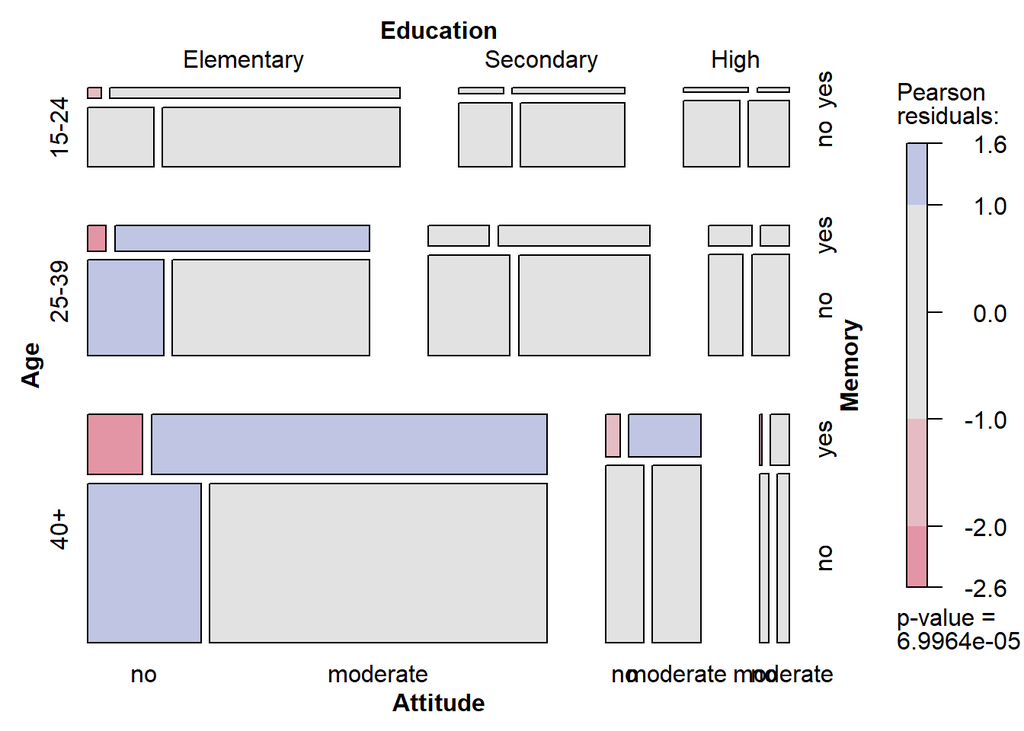

```r
mosaic(~ Memory + Attitude | Age + Education, data = pun,
       shade = TRUE, gp_args = list(interpolate = 1 : 4))
```

`cotabplot`함수를 이용하지 않고 `mosaic`함수에서도 `|`표현을 이용하여 다중 모자이크 플롯을 이용할 수 있다. 하지만 패널로 나누어진 **cotabplot**에 비해 한 눈에 보기 어렵다는 것을 알 수 있다.  
하지만, **mosaic**를 이용할 경우, **cotabplot**과 다르게 나이와 교육수준의 조합에 대한 타일의 상대적 크기를 결정해주는 것을 살펴볼 수 있다.

두 그림을 봤을 때, **Education = elementary**인 경우 연령이 높아질수록 **Attitude**와 **Memory** 사이에 연관성이 강해지는 것을 확인할 수 있다.

특히, .**Education = elementary, age = 40+**그룹의 경우 **Attitude = no**일때에는 **Memory = no**일 관찰빈도가 높지만, **Attitude = Yes**일때에는 **Memory = Yes**일 관찰빈도가 높아지는 것을 확인할 수 있다.

## 5.6 Mosaic matrices for categorical data

### 5.6.1 Mosaic matrices for pairwise associations

*Example 5.12: Bartlett data on plum-root cuttings*

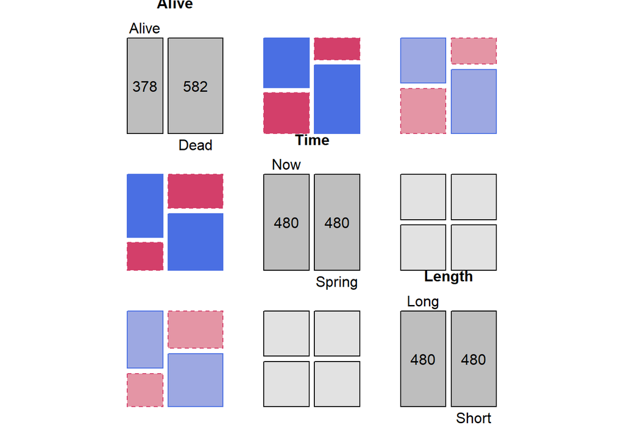

```r
pairs(Bartlett, gp = shading_Friendly2)
```

`pairs`함수는 일반적으로 연속형 변수에 대해 모든 연속형 변수의 쌍별 조합을 하나의 패널안에 나타내 패턴을 찾고자할때 사용한다. 하지만, 연속형 변수뿐만 아니라 범주형 변수에서도 산점도 행렬을 통해 쉽게 패턴을 감지할 수 있다.  
- `pairs(x)`

- x: 산점도 행렬을 그릴 데이터

`Bartlett`데이터는 자른 길이와 심은 시간이 생존에 미치는 영향을 조사하기 위한 데이터로 `vcdExtra`패키지에 포함돼있다.

- Length: 자른 길이 (Factor variable - Long, Short)
- Time: 심은 시간 (Factor variable - Now, Spring)
- Alive: 생존여부 (Factor variable - Alive, Dead)

`pairs`함수를 범주형 자료에 사용할 경우 위와 같은 그림을 얻을 수 있다. 모자이크 플롯과 더불어 각 범주형 변수의 수준에 대한 열과 행의 합을 도출해준다.

위의 모자이크 그림을 통해 **Alive & Time**, **Alive & Length** 사이에서는 연관성이 존재하는 것처럼 보이지만, **Time & Length** 사이에서는 연관성이 존재하지 않는 것(독립)처럼 보인다.

*Example 5.13: Marital status and pre- and extramarital sex*

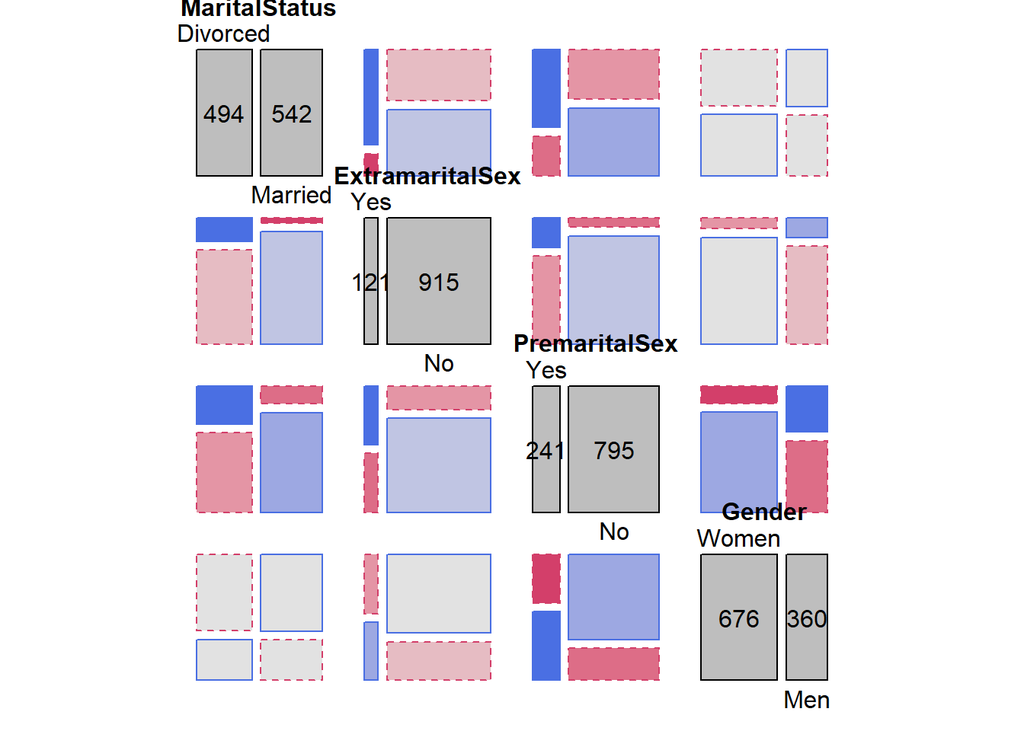

```r
data("PreSex", package = "vcd")
pairs(PreSex, gp = shading_Friendly2, space = 0.25,
      gp_args = list(interpolate = 1:4),
      diag_panel_args = list(offset_varnames = -.5))
```

`PreSex`데이터에 `pairs`를 적용하여 다중 모자이크 플롯, 변수의 행과 열의 총빈도를 살펴본 결과이다.  
대략적인 모자이크 플롯을 봤을 때, **Divorced & Gender**변수(모자이크 플롯을 살펴보면 음영이 진하지 않고 선의 형태만 바뀐것을 볼 수 있으므로, 독립이다.)를 제외한 나머지 변수끼리는 어느 정도 연관성이 존재하는 것처럼 보인다.

*Example 5.14: Berkeley admissions*

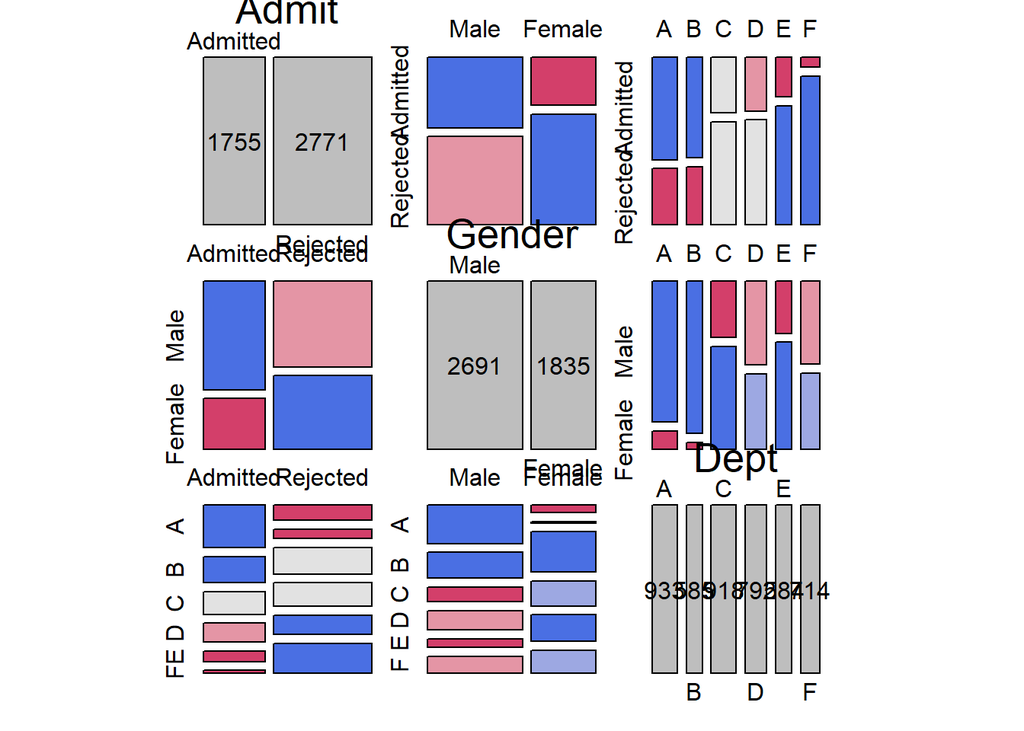

```r
largs <- list(labeling = labeling_border(varnames = FALSE,
                                         labels = c(T,T,F,T),
                                         alternate_labels = FALSE))
dargs <- list(gp_varnames = gpar(fontsize = 20), offset_varnames = -1, labeling = labeling_border(alternate_labels = FALSE))
pairs(UCBAdmissions, shade = TRUE, space = 0.25,
      diag_panel_args = dargs,
      upper_panel_args = largs,
      lower_panel_args = largs)
```

위의 그림은 `UCBAdmissions` 데이터에 `pairs`함수를 적용하여 나타낸 결과이다. `UCBAdmissions`데이터에서 **Dept**변수의 경우 많은 수준을 가지고 있기 때문에, 폰트, 여백등 다양한 옵션을 조정하여 시각화를 세밀하게 조정한 것을 살펴볼 수 있다.

`Admit`을 볼 때, **Admit = Admitted** 보다 **Admit = Rejected**가 더 많은 것을 볼 수 있고, `Gender`의 경우에는 **Gender = Female**보다 **Gender = Male**이 지원자가 더 많은 것을 확인할 수 있다.

**Gender & Admit**의 관계를 살펴보면, **Gender = Male**이 **Gender = Female**보다 **Admit = Admitted**이 더 많이 되는 경향이 있음을 보여준다.  
**Gender & Dept**의 관계를 살펴보면, **Gender = Male**은 **Dept = A, Dept = B**에 많이 지원한다. **Gender = Female**의 경우에는 **Dept = A, Dept = B**는 적게 지원하는 반면, **Dept = C** 부서에 가장 많은 지원을 하는 것을 볼 수 있다.  
**Admit & Dept**의 관계를 살펴보면, **Dept = A, Dept = B**에 **Admit = Admitted** 경향이 높게 나타나고 있으며, **Dept = E, Dept = F**에서 **Admit = Rejected**하는 경우가 많은 것을 알 수 있다.

### 5.6.2 Generalized mosaic matrices and pairs plots

*Example 5.15: Berkeley admissions*

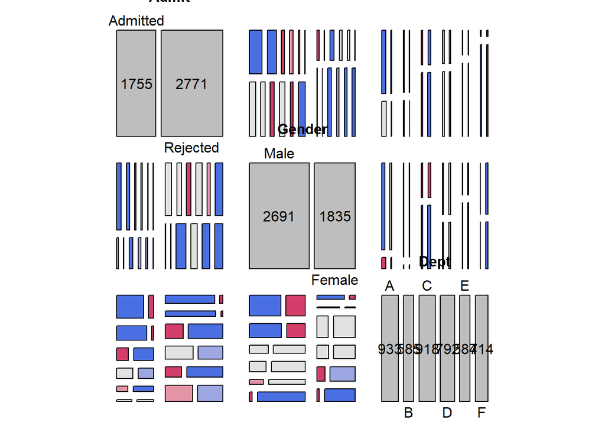

```r
pairs(UCBAdmissions, space = 0.2,
      lower_panel = pairs_mosaic(type = "joint"),
      upper_panel = pairs_mosaic(type = "total"))
```

`pairs`옵션에서 `lower_panel, upper_panel`옵션을 통해 앞서 살펴본 type을 지정할 수 있다.  
`lower_panel`은 왼쪽 아래에 3개의 모자이크 플롯을 나타내고 `upper_paenl`은 오른쪽 위에 3개의 모자이크 플롯을 나타낸다.

- type = “pairwise”: 다른 모든 변수들에 대해 **이변량 marginal** 관계를 보여준다.
- type = “total”: **상호 독립성**에 대한 모자이크 플롯을 보여준다.
- type = “conditional”: 모든 다른 변수들이 주어진 **conditional 독립성**에 대한 모자이크 그림을 보여준다.
- type = “joint”: 모든 변수 쌍의 **결합 독립성**에 대한 모자이크 플롯을 보여준다.

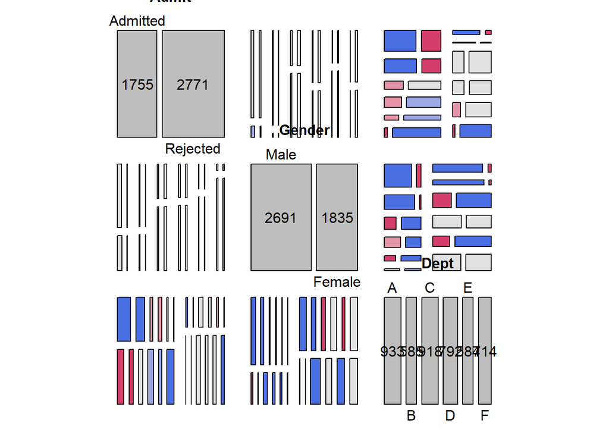

```r
pairs(UCBAdmissions, type = "conditional", space = 0.2)
```

위 그림의 경우, `type = conditional`으로 지정했기 때문에 모든 다른 변수들이 주어진 conditional 독립성에 대한 모자이크 그림을 보여준다.  
앞서 살펴본 그림과 다르게, conditional 독립성을 가정하고 살펴보게 되면, **Admit**변수와 **Gender**변수는 관련성이 없는 것처럼 보인다.

반면, **Gender**변수와 **Dept**변수를 살펴보면 앞서 살펴본 결과와 동일하게 **Gender = Male**의 경우에는 **Dept = A, Dept = B**에 많이 지원을하고 **Gender = Female**의 경우에는 **Dept = A, Dept = B**에는 적게 지원하며, **Dept = C**에 많이 지원하는 경향을 보인다.  
따라서, conditional 독립성을 가정해도 **Gender**와 **Dept**는 서로 연관이 있는 것처럼 보인다.

*Example 5.16: Arthritis treatment*

```r
library(gpairs)
data("Arthritis", package = "vcd")
```

`gpairs`패키지는 대부분의 데이터셋에 범주형 연속형 데이터가 모두 포함되어 있다는 가정하에 더욱 일반화된 산점도 행렬을 제공하는 패키지이다.

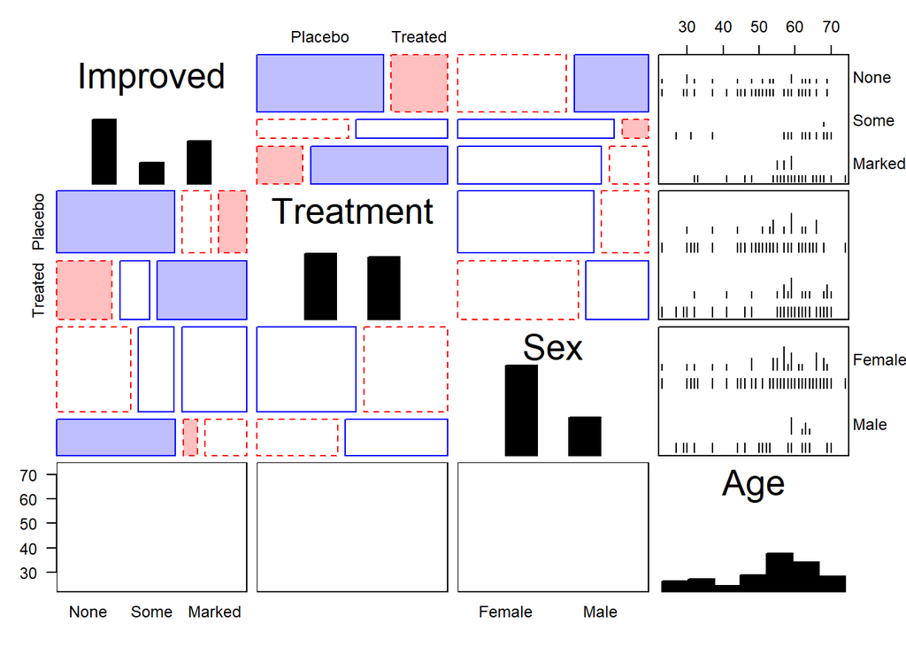

```r
gpairs(Arthritis[,c(5,2,3,4)],
       diag.pars = list(fontsize = 20),
       mosaic.pars = list(gp = shading_Friendly,
                          gp_args = list(interpolate = 1:4)))
```

`gpairs`함수는 복잡한 데이터셋에서 연속형 변수와 범주형 변수간의 패턴을 보여주는 산점도 행렬을 그릴 수 있게해주는 함수로, `gpairs`패키지안에 포함돼있다.  
- `gpairs(data,mosaic.pars)`

- data: gpairs함수를 적용할 데이터
- mosaic.pars: 산점도 행렬에 모자이크 플랏 구성 여부 (gp, gp_args를 통해 추가적인 옵션 지정 가능)

`Arthritis*`데이터에 `gpairs`함수를 적용시켜 보았다.  
출력 결과, 기존의 모자이크 플롯과 더불어 변수의 분포까지 출력해 주며, 가장 오른쪽 패널에 두 변수 간 산점도 또한 출력해주는 것을 확인할 수 있다.

**Treatment**의 경우 **Treatment = Placebo**, **Treatment = Treated**의 비율이 동일해 보이며, **Sex**의 경우 **Sex = Female**이 **Sex = Male**보다 빈도가 2배 정도 많은 것으로 보인다.

## 5.7 3D mosaics

```r
mosaic3d(Bartlett)
```

```
## 필요한 네임스페이스를 로딩합니다: rgl
```

`mosaic3d`함수는 데이터의 모자이크 플롯을 2차원이 아닌 3차원의 플롯으로 확장해주는 함수로 `vcdExtra`패키지 안에 포함돼있다.  
- `mosiac3d*(table)`

- table: 3차원의 모자이크 플롯을 적용하고자 하는 데이터

## 5.8 Visualizing the structure of loglinear models

```r
struc <- array(c(6,10,312,44,37,31,192,76),
               dim = c(2,2,2),
               dimnames = list(Age = c("Young", "Old"),
                               Sex = c("F","M"),
                               Disease = c("No","Yes")))

struc <- as.table(struc)
structable(struc)
```

```
##               Sex   F   M
## Age   Disease
## Young No            6 312
##       Yes          37 192
## Old   No           10  44
##       Yes          31  76
```

임의의 데이터 `struc`를 생성한 후, 테이블 형태로 바꿔주었다.

- Disease: 질병여부 (Factor variable - No,Yes)
- Age: 나이 (Facotr variable - Young, Old)
- Sex: 성별 (Factor variable - F,M)

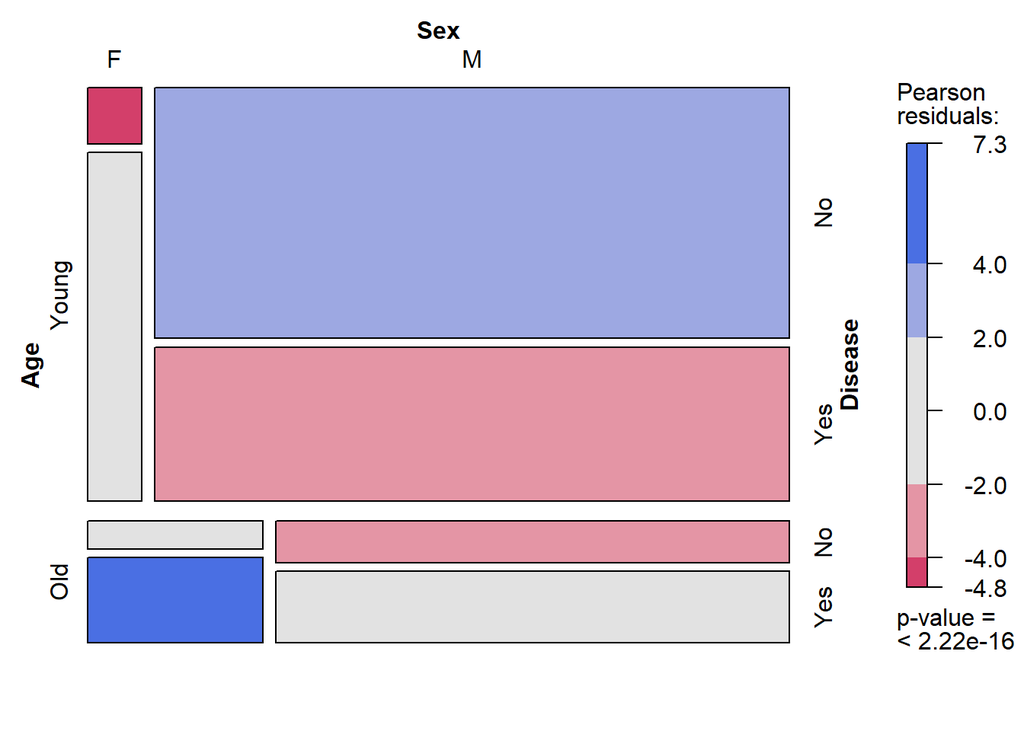

```r
mosaic(struc, shade = TRUE)
```

모자이크 플롯을 살펴본 결과, **Age = Young, Sex = M**인 경우 질병 발생 빈도가 낮지만, **Age = Old, Sex = M** 질병 발생 빈도가 높은 것을 확인할 수 있다.  
**Sex = F**의 경우, **Age = Young**일 때 질병 발생 빈도가 높지만, **Age = Old**일 경우에도 질병 발생 빈도가 높은 것을 확인할 수 있다.  
유의확률이 유의수준 0.05보다 작으므로 귀무가설을 기각하므로 **Sex,Age**는 **Disease**와 독립이 아닌 것을 알 수 있다.

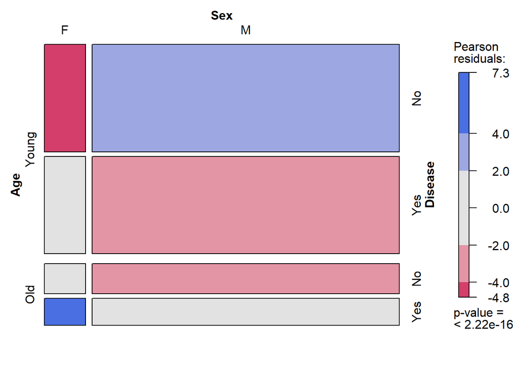

```r
mosaic(struc, type = "expected",shade=TRUE)
```

기대빈도를 통해 모자이크 플롯의 타일을 재구성한 결과, 관찰빈도와 비슷한 모자이크 플롯이 구성되는 것을 확인할 수 있다.  
유의확률이 유의수준 0.05보다 작으므로 귀무가설을 기각하므로 **Sex,Age**는 **Disease**와 독립이 아닌 것을 알 수 있다.

### 5.8.1 Mutual independence

```r
mutual <- loglm(~ Age + Sex + Disease, data = struc, fitted = TRUE)
fit <- as.table(fitted(mutual))
structable(fit)
```

```
##               Sex          F          M
## Age   Disease
## Young No           34.099109 253.307670
##       Yes          30.799196 228.794025
## Old   No           10.036484  74.556737
##       Yes           9.065211  67.341569
```

**Age,Sex,Disease** 변수들의 상호 독립을 가정한 후, 주어진 데이터를 로그 선형 모델에 적합시켜보았다.  
`fit`변수는 적합된 로그 선형 모델을 통해 기대빈도를 구한 결과이다.

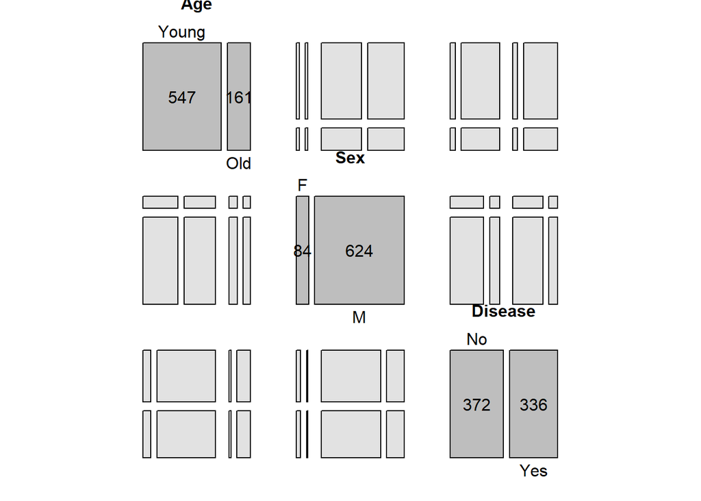

```r
pairs(fit,gp = shading_Friendly2, type = "total")
```

적합된 로그 선형 모델의 기대빈도를 이용하여 **모자이크 플롯**을 그려보았다.  
하지만, 기대빈도를 통해 재구성한 모자이크 플롯은 위와 같이 **세 변수간 연관성이 없는 것** 처럼 보인다.

```r
mosaic3d(fit)
```

`mosaic3d`함수를 통해 `fit`변수의 적합된 값에 대한 **3D 모자이크 플롯**을 그릴 수 있다.

### 5.8.2 Joint Independence

```r
joint <- loglm(~ Age * Sex + Disease, data = struc, fitted = TRUE)
fit <- as.table(fitted(joint))
structable(fit)
```

```
##               Sex         F         M
## Age   Disease
## Young No           22.59322 264.81356
##       Yes          20.40678 239.18644
## Old   No           21.54237  63.05085
##       Yes          19.45763  56.94915
```

**Disease**변수가 **Age, Sex**변수에 대해서 공동으로 독립이라고 가정한 후, 다시 한 번 로그선형모델에 적합시켜보았다.

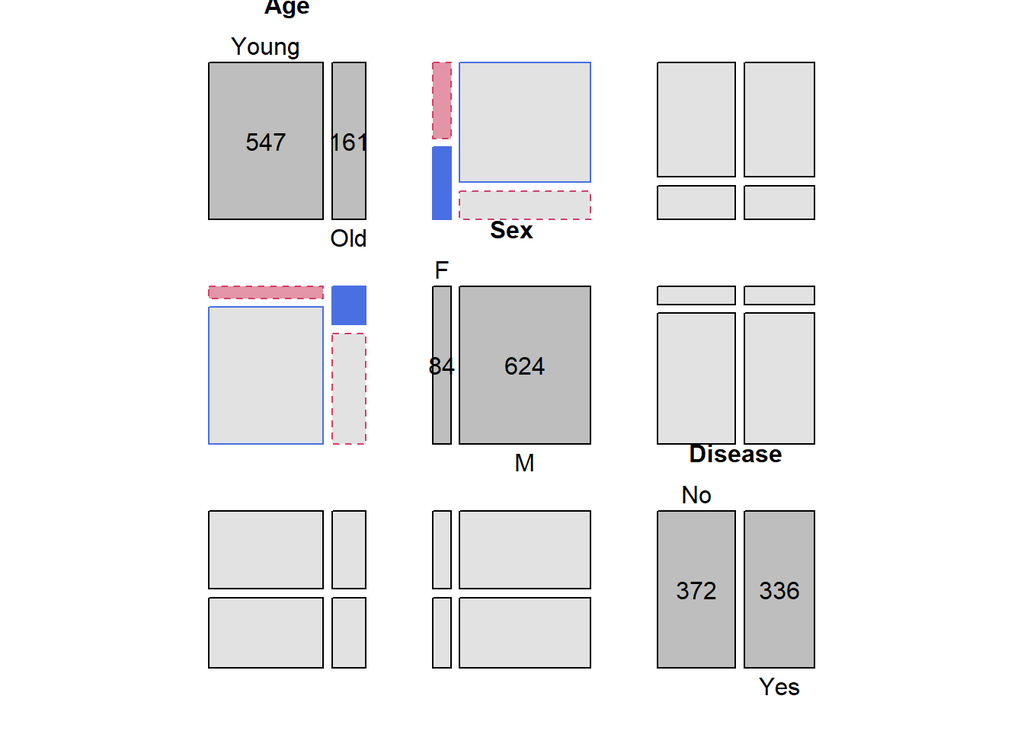

```r
pairs(fit, gp = shading_Friendly2)
```

## 5.9 Related visualization methods

`Doubledecker plot`은 추가 범주형 변수에 대한 범주형 변수 (전형적으로 이항)의 의존성을 시각화한다. 즉, 종속 변수를 나타내는 변수를 제외한 모든 독립 변수에 대해 수직 분할이 있는 모자이크 플롯이다.  
이를 통해, 설명 변수의 조합과 관련된 조건부 반응 비율 간의 차이를 더 쉽게 읽을 수 있다는 장점이 있다.

`Doubledecker plot`은 `vcd`패키지 안에 포함돼있다.  
- `Doubledecker(formula,data)`

- formula: 데이터에서 사용할 변수들 및 Doubledecker의 구성 형태 지정(일반적으로 종속변수 ~ 설명변수 + 설명변수 +…의 형태)
- data: Doubledecker 그림을 그릴 데이터

### 5.9.1 Doubledecker plots

*Example 5.18: Berkeley admissions*

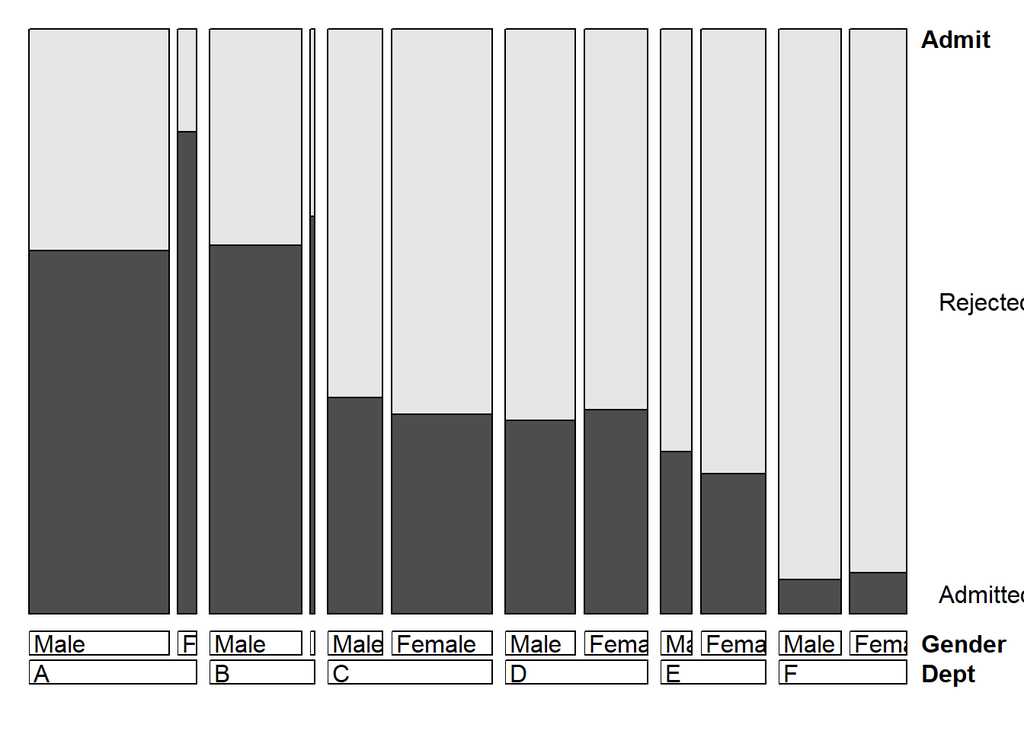

```r
doubledecker(Admit ~ Dept + Gender, data =UCBAdmissions[2:1,,])
```

`UCBAdmissions`데이터를 통해 더블데커 플랏을 그려보았다.  
종속변수의 수준에 따라 음영처리를 한 것을 볼 수 있다(**Admit = Admitted: 검은색**, **Admit = Rejected: 회색**).  
**Dept = A, Dept = B**의 경우에는 **Gender = Male**의 직사각형의 너비가 **Gender = Female**보다 넓은 것으로 보아 더 많이 지원한 것을 알 수 있으며, **Dept = C, Dept = E**에서는 **Gender = Female**이 **Gender = Male**보다 지원을 많이 했고 **Dept = D, Dept = F**에서는 **Gender = Male, Gender = Female** 모두 동일한 지원 빈도를 보여준다.  
**Gender = Male, Gender = Female** 모두 **Dept = A, Dept = B**에서 **Admit = Admitted**가 제일 높은 것을 볼 수 있다.

*Example 5.18: Titanic data*

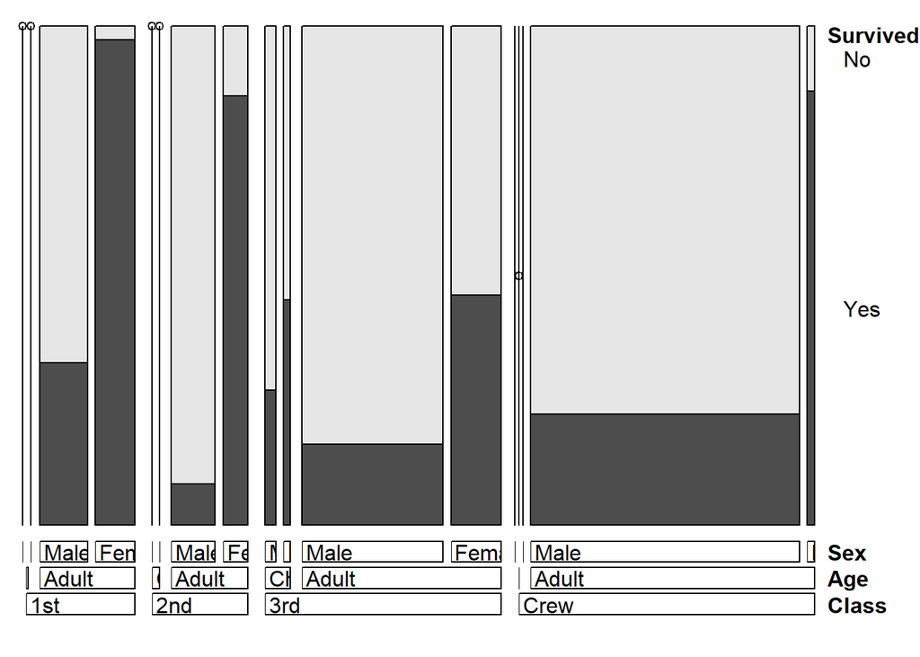

```r
doubledecker(Survived ~ Class + Age + Sex, Titanic)
```

`Titanic` 데이터에 대한 더블데커 플랏을 그려보았다. 모든 Class에서 **Sex = Female**의 **Survived = Yes**빈도가 높으며, **Sex = Male**의 경우 **Survived = Yes**가 낮은 것을 확인할 수 있다.  
또한, **Class = Crew**인 곳에 사람이 가장 많이 타고 있는 것을 알 수 있으며, **Age = Children**의 경우 **Class = 3rd**인 곳에 가장 많이 탑승한 것을 볼 수 있다.

### 5.9.2 Generalized odds ratios

*Example 5.20: Corporal punishment data*

```r
data("Punishment", package = "vcd")
pun_lor <- loddsratio(Freq ~ memory + attitude | age + education,
                      data = Punishment)
pun_lor_df <- as.data.frame(pun_lor)
```

`loddsratio`함수를 통해 `Punishment`데이터의 로그 오즈비를 구한 후, `pun_lor_df` 객체에 데이터프레임의 형태로 저장해 주었다.

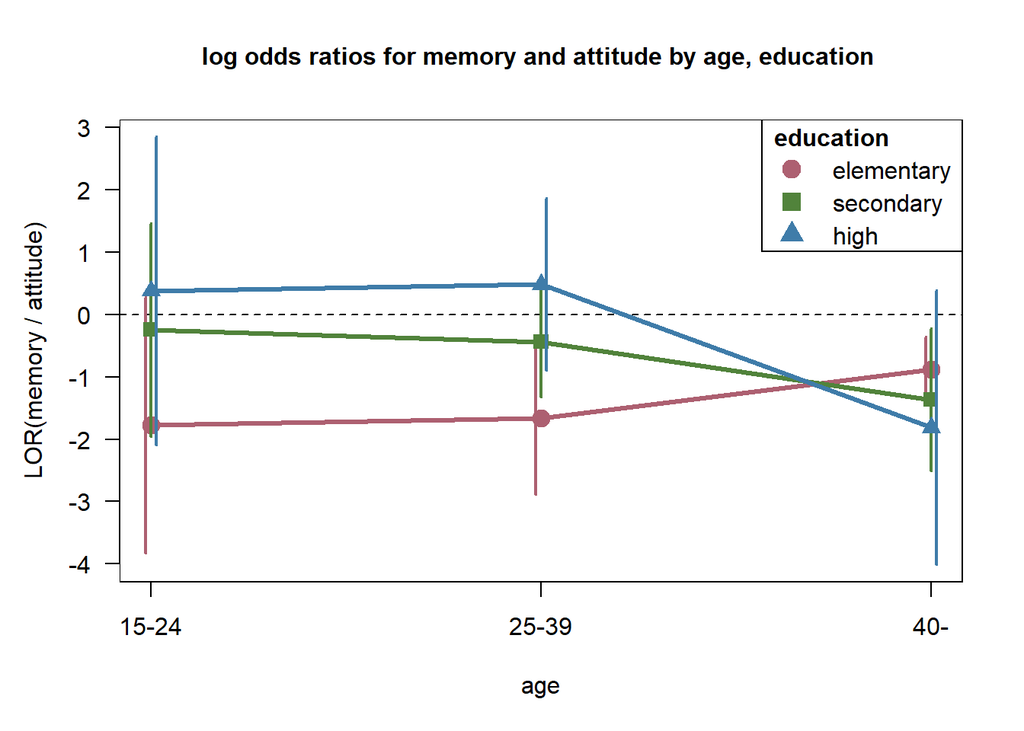

```r
plot(pun_lor)
```

오즈비가 저장된 객체를 plot의 입력값으로 주게 되면 위와 같이 인자의 수준에 따른 오즈비의 변화를 보여준다.

**Education = high**의 경우, **age**그룹의 나이가 증가함에 따라서 **로그오즈비**가 낮아지는 경향이 있고 **Education = Elementary**의 경우, **age**그룹의 나이가 증가함에 따라서 **로그오즈비**가 증가하는 경향이 있다.

즉, 최종학력이 고등학교인 사람들의 경우 처벌에 대한 기억이 나이가 증가할수록 점점 사라지지만, 최종학력이 초등학교인 사람들의 경우 처벌에 대한 기억이 나이가 증가할수록 점점 높아지는 것을 알 수 있다.

```r
pun_lor_df <- transform(pun_lor_df,
    age = as.numeric(age),
    education = as.numeric(education))

pun_mod <- lm(LOR ~ age * education, data = pun_lor_df,
              weights = 1 / ASE^2)
anova(pun_mod)
```

```
## Analysis of Variance Table
##
## Response: LOR
##               Df Sum Sq Mean Sq F value  Pr(>F)
## age            1 1.0437  1.0437  2.7167 0.16022
## education      1 1.8395  1.8395  4.7883 0.08028 .
## age:education  1 5.0441  5.0441 13.1299 0.01516 *
## Residuals      5 1.9208  0.3842
## ---
## Signif. codes:  0 '***' 0.001 '**' 0.01 '*' 0.05 '.' 0.1 ' ' 1
```

**로그오즈비**를 **age,education** 변수에 대한 선형회귀모형으로 적합시켜 보았다.  
`anova`를 통해 **age,education**의 상호작용에 대한 유의성 검정을 진행한 결과, 유의확률이 0.015로 유의수준 0.05보다 작다. 따라서, **age,education**간의 상호작용은 유의한 변수임을 알 수 있다.

*Example 5.21: Titanic data*

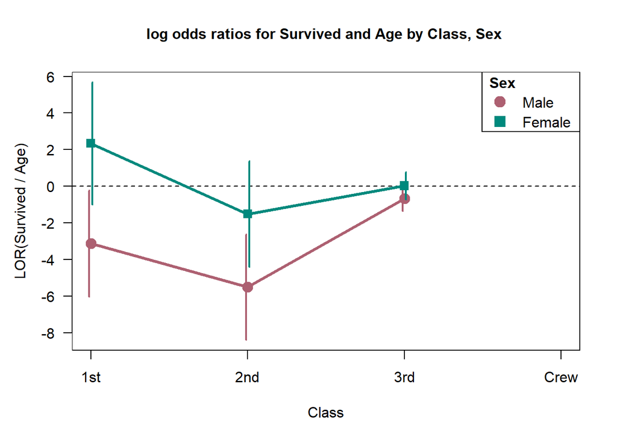

```r
Titanic2 <- Titanic[, , 2:1, 2:1]

Titanic2["Crew", , "Child",] <- NA
titanic_lor1 <- loddsratio(~ Survived + Age | Class + Sex,
                           data = Titanic2)
plot(titanic_lor1)
```

`Titanic`데이터의 생존 오즈비를 나이에 따라 살펴보았다.

성인의 생존 로그오즈비 대 아동의 생존 로그오즈비를 비교해 봤을 때, 여성의 생존 로그 오즈비가 항상 남성보다 높은 것을 확인할 수 있다.

남성과 여성 모두, **Class가 1st -> 2nd** 변할 때 로그오즈비가 작아지다가 **Class가 2nd -> 3rd**로 변할 때 로그오즈비가 커지는 것을 확인할 수 있다.  
특히, **Class = 1st, Class = 2nd**에서는 남성과 여성의 로그오즈비 차이가 크지만 **Class = 3rd**일때 로그오즈비의 차이가 크게 줄어든다.  
이를 통해, 여성의 경우에는 **class = 1st**일 때, 그렇지 않은 경우보다 생존할 오즈가 **10.40(exp(2.3425))**배 높았고 남성의 경우에는 **Class = 3rd**일 때, 그렇지 않은 경우보다 생존할 오즈가 **0.512(exp(-0.6687))**배 높았다는 것을 확인할 수 있다.

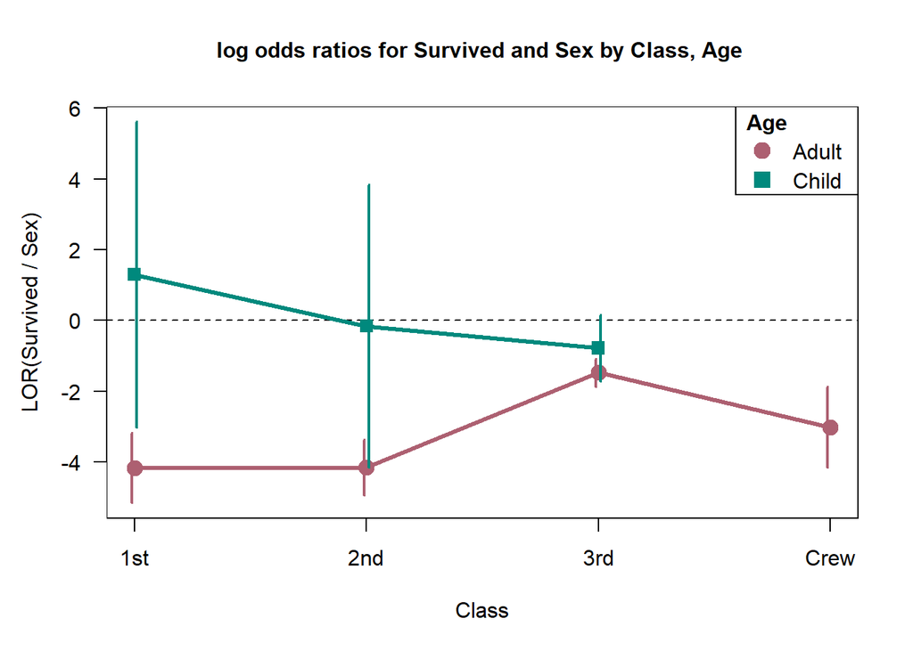

```r
titanic_lor2 <- loddsratio(~ Survived + Sex | Class + Age,
                           data = Titanic2)
plot(titanic_lor2)
```

```r
exp(titanic_lor2$coefficients)
```

```
##  1st:Adult  2nd:Adult  3rd:Adult Crew:Adult  1st:Child  2nd:Child  3rd:Child
## 0.01554124 0.01573901 0.22794856 0.04901693 3.66666667 0.85185185 0.45896066
## Crew:Child
##         NA
```

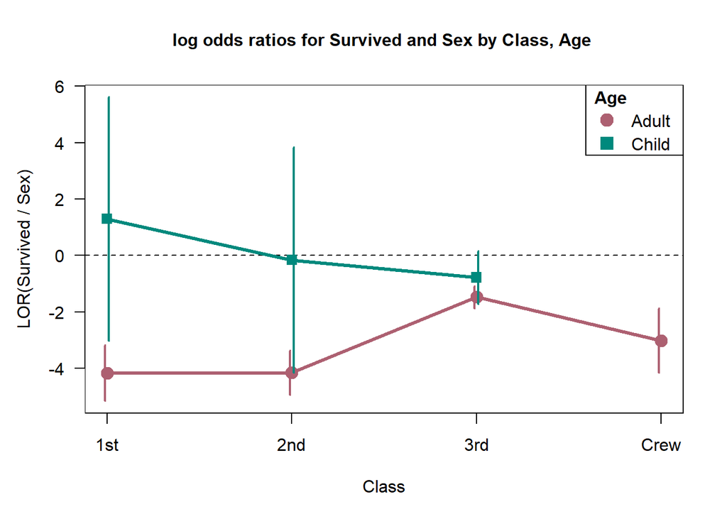

```r
plot(titanic_lor2)
```

`Titanic`데이터의 생존 로그오즈비를 성별에 따라 살펴보았다.

남성의 생존 로그오즈비 대 여성의 생존 오즈비는 성인보다 항상 어린아이의 생존오즈비가 더 높은 것을 확인할 수 있다.

어린이의 경우, **Class = 1st**에서 **Class = 3rd**로 이동함에 따라, 로그오즈비가 낮아지는 것을 확인할 수 있고 성인의 경우, **Class = 1st**에서 **Class = 3rd**로 이동함에 따라, 로그오즈비가 증가하는 것을 볼 수 있다.

어린이는 **Class = 1**일때, 그렇지 않은 경우보다 생존할 오즈가 **exp(1.2992) = 3.667**배 높은 것을 알 수 있고, 성인의 경우 **Class = 3rd**에서, 그렇지 않은 경우보다 생존할 오즈가 **exp(-1.47) = 0.23**배 높은 것을 알 수 있다.

### 5.9.3 Dount plot

`Donut plot`은 **pie chart**와 비슷하지만, **pie chart**와 다르게 중간이 뚫려 있다는 차이점이 있다.  
**pie chart**의 경우 중간이 뚫려있지 않고 채워져있기 때문에 정보를 표시하는 공간이 제한적이다. 하지만, `Dount plot`의 경우 중심의 여백을 이용해 텍스트를 추가적으로 삽입하거나 추가적인 **Pie chart**를 삽입하는 등 더 많은 정보를 표시할 수 있다는 장점이 있다.

아쉽게도 `Dount plot`을 편리하게 그리기 위한 함수를 R에서 제공하고 있지 않기 때문에 `ggplot2`패키지의 `ggplot`함수를 통해 시각화할 수 있다.

```r
library(ggplot2)
data <- data.frame(language = c("SPSS","Minitab","R","Python"), Freq = c(4,5,7,12)) # 데이터 생성
data$fraction <- cumsum(data$Freq / sum(data$Freq)) # 데이터의 퍼센트 구하기
data$ymax <- cumsum(data$fraction) # 누적합 구하기. 각 데이터의 끝을 나타냄.
data$ymin <- c(0, head(data$ymax, n = -1)) # 각 데이터의 하단을 나타냄.
data$labelPosition <- (data$ymax + data$ymin) / 2
data$label <- paste0(data$language, "\n Frequency: ", data$Freq)
head(data)
```

```
##   language Freq  fraction      ymax      ymin labelPosition
## 1     SPSS    4 0.1428571 0.1428571 0.0000000    0.07142857
## 2  Minitab    5 0.3214286 0.4642857 0.1428571    0.30357143
## 3        R    7 0.5714286 1.0357143 0.4642857    0.75000000
## 4   Python   12 1.0000000 2.0357143 1.0357143    1.53571429
##                    label
## 1    SPSS\n Frequency: 4
## 2 Minitab\n Frequency: 5
## 3       R\n Frequency: 7
## 4 Python\n Frequency: 12
```

위의 데이터는 임의로 생성한 데이터로, 통계분석을 위한 컴퓨터 프로그래밍 언어 중 어떠한 언어를 선호하는지에 대해 나타내는 데이터이다.  
`fraction`은 빈도의 누적 비율을 나타내고, `ymax`는 각 비율에 대한 누적합을 구한 결과로 각 데이터의 끝을 나타내며, `ymin`은 각 데이터의 하단을 나타낸다.  
`labelPosition`은 `donutplot`에서 `text`를 표시하고자 할 때, 각 영역의 중앙에 오도록 **(ymax + ymin)/2**로 설정한 값이다.

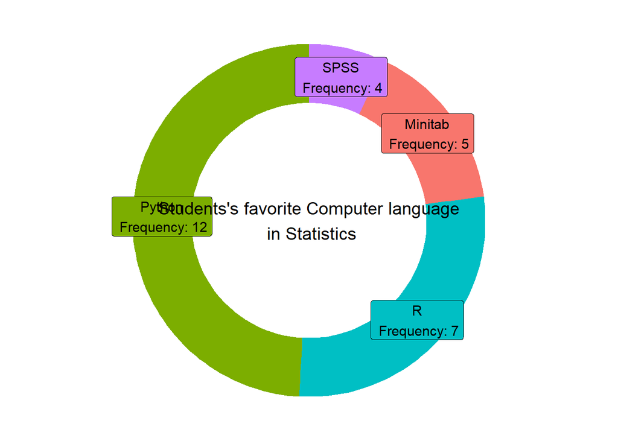

```r
ggplot(data,aes(ymax = ymax, ymin = ymin, xmax = 4, xmin = 3, fill = language))+
  geom_rect() +
  geom_label(x = 3.5, aes(y = labelPosition, label = label), size = 4) +
  coord_polar(theta = "y") +
  xlim(c(1,4)) +
  theme_void() +
  theme(legend.position = "none") +
  annotate(geom = "text", x = 1, y =2, label = "Students's favorite Computer language\n in Statistics",size = 5,
           color = "Black")
```

`dount plot`을 그리기 위해서는 위에 얻어진 데이터를 이용해 `geom_rect`함수를 통해 직사각형을 그린 후, 이 직사각형의 앞부분을 짜르게 된다.  
직사각형의 앞부분을 짜른 후, `coord_polar`함수를 이용하여 원형으로 바꿔주게 되면 직사각형의 앞면이 뚫려있으므로, 원형으로 바꿨을 때 가운데가 뚫리게 되어 `donut plot`을 완성할 수 있게 된다.

`annotate`함수는 원하는 위치에 원하는 텍스트를 넣을 수 있게 하는 옵션으로, 뚫린 가운데 원에 제목을 넣기 때문에 시각화한 결과를 조금 더 한 눈에 들어올 수 있게 만들어준다.

### 5.9.4 Balloon plot

`Balloon plot`은 교차표로 만들어진 데이터를 시각화 하는데 유용하게 사용되는 기법 중 하나로, R에서는 `gplots`패키지에 포함된 `Balloonplot`함수를 이용하여 그릴 수 있다.

`gplots`패키지는 데이터를 시각화하기 위한 도구로 회귀진단에 사용되는 `lmplot2, residplot`, 신뢰구간을 시각화하기 위한 `plotCI, plotmeans`등 다양한 향상된 시각화 함수들을 제공하는 패키지이다.  
- `balloonplot(data,label,show.margins)`

- data: balloonplot을 그릴 데이터 (반드시 교차표의 형태)
- label: 빈도표시 여부
- show.margins: margin 테이블 표시 여부

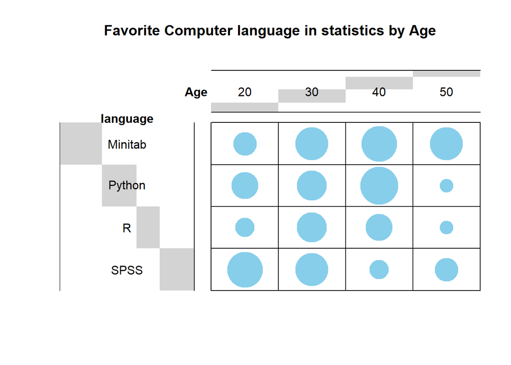

```r
set.seed(42)
library(gplots)
data1 <- data.frame(Age = c(rep("20",16),rep("30",22),rep("40",21),rep("50",11)))
data2 <- sample(c("SPSS","Minitab","R","Python"),70,replace=TRUE)
data1 <- cbind(data1,data2)
colnames(data1)[2] <- "language"
df <- xtabs(~Age + language, data = data1)
balloonplot(df, main = "Favorite Computer language in statistics by Age",label =FALSE,show.margins = FALSE)
```

데이터의 경우, 앞서 사용한 학생들이 가장 좋아하는 컴퓨팅 언어에서 연령 변수를 추가하여 연령에따른 컴퓨팅 언어 선호도 데이터를 만들어주었다.  
`balloonplot`함수를 사용하여 위와 같은 그림을 얻을 수 있다.

각 셀에 위치한 풍선처럼 생긴 원은 각 셀의 빈도를 나타낸다. 원이 클수록 셀의 빈도가 높다는 의미이고 원이 작을수록 셀의 빈도가 낮다는 의미이다.

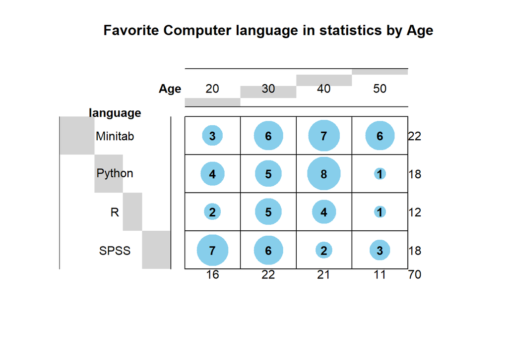

```r
balloonplot(df, main = "Favorite Computer language in statistics by Age",
            label = TRUE,
            show.margins = TRUE)
```

`label, show.margins`옵션을 `TRUE`로 지정하게 되면 각 셀마다의 빈도 및 셀의 **marginal sum**을 출력하도록 만들어 줄 수 있다.  
제일 많이 선호되는 언어는 Minitab이 22명으로 가장 많고, 연령대의 경우 22명으로 30대가 가장 많은 것을 쉽게 살펴볼 수 있다.  
20대의 경우 SPSS를 선호하며, 30대의 경우 모든 컴퓨팅 언어가 거의 비슷한 빈도를 가지며, 40대의 경우에는 Minitab, Python을, 50대의 경우에는 Minitab을 가장 선호하는 것을 볼 수 있다.

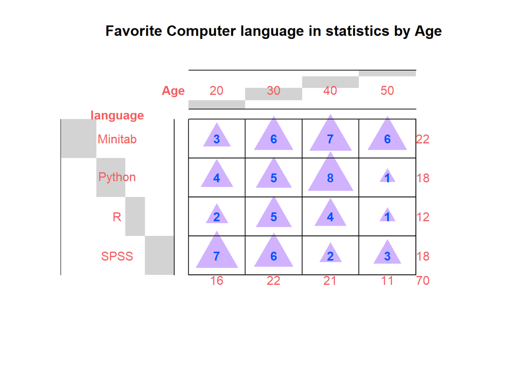

```r
balloonplot(df, main = "Favorite Computer language in statistics by Age",
            label = TRUE,
            show.margins = TRUE,
            dotcolor = "#D1B2FF",dotchar = 17,
            label.color="#0054FF",text.color = "#F15F5F")
```

`dotcolor, dotchar, label.color, text.color`을 통해 도형, 텍스트의 색깔이나 모양을 쉽게 바꿔줄 수 있다.

** Summary of Chapter5

- **모자이크 플롯**은 2-way, 3-way, … , n-way등의 고차원 분할표를 시각화하고 변수들의 패턴을 파악하는데에 유용하게 사용할 수 있는 방법이다.
- **로그선형모델**은 고차원의 분할표를 이용하는 경우, 다양한 독립성 유형의 모델을 가정한 후, 데이터를 모형에 적합시키고 싶을 때, 사용할 수 있는 방법이다. * 흔히 자주 사용되는 독립성 유형으로는 모든 변수가 상호독립이라는 가정을 하는 **Complete Independence**, 특정 변수들이 분석하고자 하는 변수에 대한 공동적인 독립이라는 가정을 하는 **Joint Independence**, 특정 변수들이 제어될 때 분석하고자 하는 변수들이 조건부 독립이라는 가정을 하는 **Conditional Independence**, 어떠한 쌍도 독립적이지않다 라는 가정을 하는 **No three -way interaction**유형이 있다.
- 3원 분할표 혹은 고차원의 분할표에서 분석하고자 하는 두 변수 사이에 계층 변수인 C가 일부 수준에서는 연관되지만 다른 수준에서는 연관되지 않을 수 있다. 이러한 경우, 전체 모형에 대해 영향을 끼치게 되므로 부분적으로 계층 변수의 수준에 따라 두 변수의 관계가 어떻게 변하는지 탐구하는 것이 필요하다. 이러한 방법을 **부분 연관(Partial association)**이라고 한다.
- **산점도 행렬**은 일반적으로 연속형 변수의 패턴을 보기위해 많이 사용하지만, 범주형 변수의 패턴을 보기위해 사용할수도 있다.
- **오즈비**의 변화를 단순히 결과창을 통해 해석하면서 비교하는 것보다는 한 객체에 저장한 후, `plot`함수를 통해 변수의 수준 변화에 따라 어떻게 변하는지 보는 것이 좋다.